```python
# Dependencies

!pip install geodatasets

import pandas as pd
import numpy as np
from datetime import datetime
import requests
import geopandas as gpd
import random

import matplotlib.pyplot as plt
import seaborn as sns
import plotly.offline as py
from branca.colormap import linear

import folium
from folium.plugins import MarkerCluster
from folium.plugins import HeatMap
from folium.plugins import TimeSliderChoropleth

from shapely.geometry import Point

from sklearn.model_selection import train_test_split
from sklearn.linear_model import LinearRegression
from sklearn.metrics import mean_squared_error, r2_score
from sklearn.metrics import mean_absolute_error, root_mean_squared_error

#from datascience import *
from collections import Counter
from scipy import stats
%matplotlib inline
plt.style.use('fivethirtyeight')
import plotly.express as px
```

# **Our Question:**

We want to explore the relationship between legalized abortion and violent crime rates in the U.S. The idea is to see whether access to abortion services has any measurable impact on crime outcomes.

# **Why This Matters:**

Understanding the relationship between legalized abortion and violent crime rates could shed light on how major policy decisions affect long-term social outcomes. If there is a strong link, it may help inform how we approach future legislation, reproductive rights, and crime prevention strategies. We also want to explore how other factors—like political leanings, alcohol consumption, and general fertility trends—also interact with abortion access and crime rates.

# **Data:**

To answer our question, we used and analyzed several datasets:

- Guttmacher Pregnancies
- Births and Abortions in the US (1973-2020)
- FBI Crime Data Explorer for estimated crime and arrests data
- MIT Election lab data on presidential, senate, and house races
- National Institute on Alcohol Abuse and Alcoholism data archive

# **Approach:**

We’re focusing on correlation coefficients as our main unit of analysis—specifically, how abortion access measures relate to violent crime rates over time. Our methodology will draw from work like Donohue & Levitt’s cohort-based analysis, but with less emphasis on causal claims and more on observable trends across data.

# **Exploratory Data Analysis (EDA)**

This EDA only concerns the first three datasets (abortion, pregnancies, and arrest/crime data). The other datasets are supplements that were not in our initial exploration of data. For these supplementary datasets, EDA can be found under our Modelling sections.

```python
path = "data/"
```

```python
# Load the CSV files
arrests_data = pd.read_csv(path + 'arrests_national.csv', on_bad_lines='skip', low_memory = False)
abortion_data = pd.read_csv(path + 'NationalAndStatePregnancy_PublicUse.csv', on_bad_lines='skip', low_memory = False)
estimated_crime = pd.read_csv(path + 'estimated_crimes_1979_2023.csv', dtype={'state_abbr':str,'year':np.int64,'state_name':str})
```

```python
#estimated_crime.head()
```

```python
#abortion_data.head()
```

```python
#arrests_data.head()
```

## estimated_crime

### Clean & filter estimated_crime df

- contains only violent crime related crimes
- change object type to float type for applicable columns
- fills NaN values with 0

```python
# takes series; removes commas + change dtype of columns from objects to floats
def to_floats(x):
  x = x.str.replace(',','')
  return x.astype(float)

float_columns = ['population','violent_crime','homicide','rape_revised','robbery','aggravated_assault','property_crime','burglary','larceny','motor_vehicle_theft']
estimated_crime[float_columns] = estimated_crime[float_columns].apply(to_floats)
```

```python
# final violent crime table
violent = estimated_crime.drop(['property_crime','burglary','larceny','motor_vehicle_theft','caveats', 'state_name'], axis=1).rename(columns={'violent_crime':'total_violent','state_abbr':'state'}) # already confirmed that violent_crime is the sum of remaining categories
violent[violent.columns[3:]] = violent[violent.columns[3:]].fillna(0)
violent['state'] = violent['state'].fillna('USA')
#violent.head()
```

## abortion_data

```python
#abortion_data.head()
```

### Handling nans

```python
abortion_data.isna().sum()
```

```
state                   0
year                    0
pregnancyratelt15      11
pregnancyrate1517       7
pregnancyrate1819       7
                     ...
abortionratiototal      0
miscarriagestotal       0
pregnanciestotal        0
notes                 845
versiondate             0
Length: 104, dtype: int64
```

```python
abortion_data = abortion_data.drop('populationsource', axis=1).drop('notes', axis=1).drop('versiondate', axis=1)

# change nans to 0 & object dtype to numerical for applicable columns; state object already works as string
abortion_data.iloc[:, 2:] = abortion_data.iloc[:, 2:].fillna(0)

abortion_data.dtypes
```

```
state                  object
year                    int64
pregnancyratelt15     float64
pregnancyrate1517     float64
pregnancyrate1819     float64
                       ...
birthratetotal        float64
abortionratetotal     float64
abortionratiototal    float64
miscarriagestotal       int64
pregnanciestotal        int64
Length: 101, dtype: object
```

## Splitting abortion_data df for readability

- new tables include:
  - abortion -- contains ratio, rate, and counts
  - preg -- contains pregnancy rate and counts
  - birth -- contains birth rate and counts
  - miscar -- contains miscarriage counts
  - pop -- contains population counts

```python
# only abortion related columns
abortion_columns = [col for col in abortion_data.columns if 'abortion' in col]
abortion_columns.append('state')
abortion_columns.append('year')
abortion_columns.reverse()

abortion = abortion_data[abortion_columns]
#abortion.head()
```

```python
# only pregnancy related columns
pregnancy_columns = [col for col in abortion_data.columns if 'preg' in col]
pregnancy_columns.append('state')
pregnancy_columns.append('year')
pregnancy_columns.reverse()

preg = abortion_data[pregnancy_columns]
#preg.head()
```

```python
# only birth related columns
birth_columns = [col for col in abortion_data.columns if 'birth' in col]
birth_columns.append('state')
birth_columns.append('year')
birth_columns.reverse()

birth = abortion_data[birth_columns]
#birth.head()
```

```python
# only miscarriage related columns
miscar_columns = [col for col in abortion_data.columns if 'miscar' in col]
miscar_columns.append('state')
miscar_columns.append('year')
miscar_columns.reverse()

miscar = abortion_data[miscar_columns]
#miscar.head()
```

```python
# only population counts
pop_columns = [col for col in abortion_data.columns if 'popu' in col]
pop_columns.append('state')
pop_columns.append('year')
pop_columns.reverse()

pop = abortion_data[pop_columns]
#pop.head()
```

```python
# totals
total_columns = [col for col in abortion_data.columns if 'total' in col]
total_columns.append('state')
total_columns.append('year')
total_columns.reverse()

totals = abortion_data[total_columns]
#totals.head()
```

```python
totals.dtypes
```

```
year                    int64
state                  object
pregnanciestotal        int64
miscarriagestotal       int64
abortionratiototal    float64
abortionratetotal     float64
birthratetotal        float64
pregnancyratetotal    float64
birthstotal             int64
abortionstotal          int64
dtype: object
```

## arrests_data

```python
#arrests_data.head()
```

### filter columns for applicable violent crimes

```python
violent_columns = ['year','population','violent_crime','homicide','rape','robbery','aggravated_assault']
arrests = arrests_data[violent_columns]
#arrests.head()
```

```python
# confirming that violent_crime column is total of these four violent crimes (yes, it is)
arrests['homicide'] + arrests['rape'] + arrests['robbery'] + arrests['aggravated_assault']
```

```
0     515151
1     505681
2     498666
3     480360
4     521196
5     534704
6     552077
7     581765
8     594911
9     597447
10    611523
11    603503
12    586558
13    597026
14    620510
15    627132
16    625243
17    636000
18    676020
19    717720
20    729910
21    796230
dtype: int64
```

```python
# no nans to handle
arrests.isna().sum()
```

```
year                  0
population            0
violent_crime         0
homicide              0
rape                  0
robbery               0
aggravated_assault    0
dtype: int64
```

## Final tables

```python
#violent.head()
```

```python
#abortion.head()
```

```python
#arrests.head()
```

## Combining violent and abortion

```python
violent.shape
abortion.shape
```

```
(1068, 35)
```

```python
abvi = pd.merge(violent, abortion)
#abvi.head()
```

```python
# aggregate mean by year
abvi.drop('state', axis=1).groupby(by='year').mean()
```

| year | population | total_violent | homicide | rape_legacy | rape_revised | robbery | aggravated_assault | abortionratiototal | abortionratetotal | abortionstotal | ... | abortionrate40plus | abortionrate3539 | abortionrate3034 | abortionrate2529 | abortionrate2024 | abortionratelt20 | abortionrate1519 | abortionrate1819 | abortionrate1517 | abortionratelt15 |
| --- | --- | --- | --- | --- | --- | --- | --- | --- | --- | --- | --- | --- | --- | --- | --- | --- | --- | --- | --- | --- | --- |
| 1988 | 4.819804e+06 | 30710.215686 | 405.392157 | 1813.450980 | 0.000000 | 10646.431373 | 17844.941176 | 350.549020 | 23.147059 | 30994.313725 | ... | 2.494118 | 7.835294 | 14.201961 | 25.023529 | 42.601961 | 36.476471 | 35.327451 | 50.217647 | 24.658824 | 6.484314 |
| 1992 | 5.001588e+06 | 37887.725490 | 465.882353 | 2138.470588 | 0.000000 | 13185.843137 | 22097.529412 | 322.423529 | 21.549020 | 29819.803922 | ... | 2.590196 | 8.164706 | 14.519608 | 25.756863 | 44.674510 | 30.074510 | 28.878431 | 43.562745 | 18.921569 | 5.854902 |
| 1996 | 5.201647e+06 | 33108.627451 | 385.196078 | 1887.294118 | 0.000000 | 10501.843137 | 20334.294118 | 294.472549 | 18.245098 | 26499.411765 | ... | 2.541176 | 7.698039 | 13.547059 | 24.662745 | 39.049020 | 24.323529 | 23.396078 | 35.650980 | 15.433333 | 4.417647 |
| 2000 | 5.518077e+06 | 27950.705882 | 305.607843 | 1768.196078 | 0.000000 | 8000.313725 | 17876.588235 | 272.486275 | 17.266667 | 25621.176471 | ... | 2.666667 | 7.956863 | 14.300000 | 25.537255 | 37.317647 | 21.345098 | 20.605882 | 31.968627 | 12.962745 | 3.778431 |
| 2005 | 5.813864e+06 | 27269.509804 | 328.235294 | 1849.941176 | 0.000000 | 8185.058824 | 16906.274510 | 249.937255 | 16.088235 | 23509.019608 | ... | 2.835294 | 8.268627 | 14.460784 | 24.013725 | 32.154902 | 16.966667 | 16.394118 | 25.747059 | 10.305882 | 2.792157 |
| 2006 | 5.870559e+06 | 28139.666667 | 339.392157 | 1852.392157 | 0.000000 | 8808.745098 | 17139.137255 | 242.035294 | 16.084314 | 23518.431373 | ... | 2.794118 | 8.345098 | 14.394118 | 23.813725 | 31.962745 | 16.723529 | 16.194118 | 25.596078 | 10.107843 | 2.578431 |
| 2007 | 5.914140e+06 | 27901.372549 | 335.843137 | 1807.058824 | 0.000000 | 8771.058824 | 16987.411765 | 239.935294 | 16.121569 | 23588.039216 | ... | 2.852941 | 8.364706 | 14.586275 | 23.390196 | 31.988235 | 16.501961 | 15.980392 | 25.188235 | 9.962745 | 2.592157 |
| 2008 | 5.961955e+06 | 27342.372549 | 322.843137 | 1779.411765 | 0.000000 | 8697.313725 | 16542.803922 | 242.631373 | 16.074510 | 23637.450980 | ... | 2.892157 | 8.374510 | 14.533333 | 23.029412 | 31.750980 | 16.223529 | 15.733333 | 24.464706 | 9.790196 | 2.578431 |
| 2009 | 6.019736e+06 | 25997.960784 | 301.941176 | 1749.823529 | 0.000000 | 8014.549020 | 15931.647059 | 238.429412 | 15.360784 | 22625.098039 | ... | 3.025490 | 8.117647 | 13.998039 | 22.192157 | 29.931373 | 14.723529 | 14.274510 | 22.300000 | 8.613725 | 2.270588 |
| 2010 | 6.065298e+06 | 24534.274510 | 288.666667 | 1678.294118 | 0.000000 | 7237.039216 | 15330.274510 | 233.266667 | 14.625490 | 21562.352941 | ... | 2.896078 | 7.915686 | 13.576471 | 21.039216 | 28.364706 | 13.490196 | 13.078431 | 20.594118 | 7.784314 | 2.096078 |
| 2011 | 6.109565e+06 | 23647.666667 | 287.470588 | 1650.490196 | 0.000000 | 6956.313725 | 14753.392157 | 225.058824 | 13.964706 | 20645.882353 | ... | 2.941176 | 7.725490 | 13.021569 | 20.245098 | 26.809804 | 12.211765 | 11.829412 | 18.976471 | 6.798039 | 1.921569 |
| 2012 | 6.154386e+06 | 23864.058824 | 291.294118 | 1669.431373 | 0.000000 | 6961.784314 | 14941.352941 | 213.207843 | 13.139216 | 19688.823529 | ... | 2.864706 | 7.574510 | 12.621569 | 19.539216 | 24.745098 | 10.452941 | 10.105882 | 16.437255 | 5.656863 | 1.633333 |
| 2013 | 6.205834e+06 | 23523.215686 | 280.764706 | 1609.980392 | 2229.313725 | 6766.529412 | 14250.529412 | 202.090196 | 12.329412 | 18758.627451 | ... | 2.668627 | 7.209804 | 12.068627 | 18.672549 | 23.031373 | 9.252941 | 8.990196 | 14.627451 | 5.113725 | 1.211765 |
| 2014 | 6.253086e+06 | 23258.529412 | 277.725490 | 1664.000000 | 2314.254902 | 6331.470588 | 14335.078431 | 195.464706 | 12.009804 | 18128.235294 | ... | 2.670588 | 7.278431 | 11.929412 | 18.566667 | 22.098039 | 8.266667 | 8.041176 | 13.390196 | 4.409804 | 0.833333 |
| 2015 | 6.292217e+06 | 24212.823529 | 311.235294 | 1789.431373 | 2473.215686 | 6433.509804 | 14981.509804 | 190.184314 | 11.654902 | 17615.294118 | ... | 2.580392 | 7.211765 | 12.054902 | 18.333333 | 20.913725 | 7.452941 | 7.258824 | 12.278431 | 3.864706 | 0.707843 |
| 2016 | 6.341293e+06 | 25207.960784 | 341.431373 | 1901.372549 | 2596.352941 | 6525.431373 | 15744.745098 | 186.400000 | 11.315686 | 17103.921569 | ... | 2.637255 | 7.031373 | 11.943137 | 18.100000 | 19.825490 | 6.956863 | 6.788235 | 11.527451 | 3.603922 | 0.666667 |
| 2017 | 6.375434e+06 | 25174.019608 | 339.098039 | 0.000000 | 2660.117647 | 6286.196078 | 15888.607843 | 190.574510 | 11.280392 | 16878.823529 | ... | 2.639216 | 7.158824 | 12.027451 | 18.005882 | 19.654902 | 6.803922 | 6.633333 | 10.752941 | 3.392157 | 0.684314 |
| 2018 | 6.405637e+06 | 24556.843137 | 321.058824 | 0.000000 | 2818.921569 | 5515.254902 | 15901.607843 | 197.800000 | 11.458824 | 17400.588235 | ... | 2.690196 | 7.223529 | 12.427451 | 18.437255 | 19.803922 | 6.894118 | 6.709804 | 11.278431 | 3.478431 | 0.760784 |
| 2019 | 6.437842e+06 | 24517.509804 | 326.843137 | 0.000000 | 2808.313725 | 5264.372549 | 16117.980392 | 204.286275 | 11.623529 | 17953.725490 | ... | 2.768627 | 7.492157 | 12.862745 | 18.719608 | 19.862745 | 6.952941 | 6.754902 | 11.507843 | 3.454902 | 0.882353 |
| 2020 | 6.460473e+06 | 25747.156863 | 422.941176 | 0.000000 | 2479.019608 | 4776.470588 | 18068.725490 | 214.245098 | 11.790196 | 18222.352941 | ... | 2.735294 | 7.370588 | 13.098039 | 19.370588 | 20.501961 | 6.809804 | 6.615686 | 11.498039 | 3.321569 | 0.823529 |

20 rows × 40 columns

```python
# aggregate mean by state
abvi.drop('year', axis=1).groupby(by='state').mean()
```

| state | population | total_violent | homicide | rape_legacy | rape_revised | robbery | aggravated_assault | abortionratiototal | abortionratetotal | abortionstotal | ... | abortionrate40plus | abortionrate3539 | abortionrate3034 | abortionrate2529 | abortionrate2024 | abortionratelt20 | abortionrate1519 | abortionrate1819 | abortionrate1517 | abortionratelt15 |
| --- | --- | --- | --- | --- | --- | --- | --- | --- | --- | --- | --- | --- | --- | --- | --- | --- | --- | --- | --- | --- | --- |
| AK | 689850.85 | 4811.65 | 40.45 | 424.45 | 408.45 | 664.00 | 3404.90 | 174.005 | 13.205 | 1896.0 | ... | 2.395 | 6.585 | 10.860 | 18.520 | 27.780 | 14.315 | 13.925 | 24.455 | 7.830 | 0.915 |
| AL | 4676132.95 | 22796.90 | 371.65 | 1170.75 | 788.60 | 5366.35 | 15384.70 | 176.355 | 11.170 | 10701.5 | ... | 1.470 | 5.015 | 9.725 | 16.530 | 22.150 | 11.520 | 10.975 | 17.185 | 6.745 | 2.875 |
| AR | 2846826.80 | 14947.55 | 201.45 | 978.05 | 832.75 | 2298.60 | 10909.25 | 138.560 | 9.290 | 5242.0 | ... | 1.530 | 4.635 | 8.270 | 13.270 | 17.970 | 9.660 | 9.225 | 14.490 | 5.705 | 2.210 |
| AZ | 6192621.15 | 29637.30 | 397.45 | 1681.90 | 1349.95 | 7281.20 | 19398.25 | 197.100 | 14.045 | 16558.0 | ... | 2.755 | 7.500 | 12.520 | 19.610 | 27.565 | 13.715 | 13.290 | 22.285 | 7.220 | 2.125 |
| CA | 36693531.15 | 193165.85 | 2170.05 | 7450.90 | 5344.75 | 64867.35 | 115099.10 | 373.575 | 25.000 | 192922.5 | ... | 4.725 | 13.290 | 22.600 | 35.470 | 48.965 | 25.315 | 24.550 | 39.535 | 14.660 | 3.805 |
| CO | 4948004.80 | 18108.45 | 181.10 | 1665.05 | 1455.15 | 3521.20 | 11762.75 | 212.325 | 13.345 | 13512.0 | ... | 2.645 | 6.885 | 11.255 | 18.295 | 27.570 | 14.960 | 14.530 | 22.940 | 8.910 | 2.180 |
| CT | 3505892.50 | 10023.55 | 119.05 | 560.45 | 319.40 | 3771.25 | 5372.95 | 388.755 | 21.715 | 15283.5 | ... | 3.560 | 11.055 | 20.375 | 34.850 | 44.205 | 22.050 | 21.410 | 32.020 | 14.210 | 3.350 |
| DC | 630337.30 | 8878.85 | 190.05 | 188.85 | 172.20 | 4059.15 | 4339.15 | 585.420 | 32.860 | 5407.0 | ... | 5.900 | 14.165 | 19.695 | 27.980 | 39.285 | 27.195 | 26.200 | 25.990 | 26.415 | 6.820 |
| DE | 877239.65 | 4912.50 | 46.05 | 288.80 | 136.80 | 1317.05 | 3175.45 | 360.745 | 22.775 | 4023.0 | ... | 3.750 | 11.415 | 20.350 | 32.920 | 44.910 | 23.540 | 22.720 | 32.795 | 15.085 | 4.200 |
| FL | 18515925.65 | 110084.65 | 1083.25 | 4767.50 | 3078.60 | 28471.90 | 73719.70 | 366.290 | 22.535 | 78690.0 | ... | 4.015 | 11.770 | 21.220 | 33.765 | 44.740 | 22.140 | 21.345 | 34.505 | 12.590 | 4.080 |
| GA | 9427752.35 | 41079.15 | 645.10 | 1842.25 | 1227.25 | 13011.20 | 24803.85 | 265.065 | 17.070 | 34286.5 | ... | 2.975 | 9.270 | 16.730 | 26.390 | 32.830 | 15.205 | 14.510 | 23.295 | 8.610 | 3.510 |
| HI | 1328130.10 | 3455.75 | 30.40 | 293.25 | 233.25 | 1064.75 | 1878.45 | 287.235 | 20.375 | 5334.5 | ... | 4.305 | 10.695 | 16.950 | 26.885 | 40.445 | 24.620 | 23.875 | 37.435 | 15.250 | 3.420 |
| IA | 3031491.40 | 8448.55 | 58.30 | 644.80 | 492.55 | 1097.20 | 6331.70 | 139.370 | 9.125 | 5408.0 | ... | 1.755 | 4.835 | 8.310 | 13.360 | 17.015 | 8.900 | 8.635 | 13.280 | 5.260 | 1.310 |
| ID | 1521507.80 | 3587.40 | 33.60 | 382.60 | 308.65 | 220.70 | 2742.65 | 105.025 | 7.675 | 2268.0 | ... | 1.685 | 4.220 | 6.755 | 10.560 | 14.890 | 7.615 | 7.415 | 12.730 | 3.895 | 0.655 |
| IL | 12624223.10 | 65973.50 | 881.20 | 3090.85 | 2118.95 | 22140.30 | 38461.80 | 287.820 | 18.215 | 47890.5 | ... | 3.280 | 9.600 | 16.660 | 26.750 | 35.305 | 18.180 | 17.545 | 27.680 | 10.905 | 3.190 |
| IN | 6384244.25 | 23635.95 | 368.80 | 1429.85 | 963.60 | 6650.50 | 14563.25 | 150.470 | 9.720 | 12677.0 | ... | 1.605 | 4.960 | 8.850 | 14.405 | 19.105 | 9.220 | 8.920 | 14.750 | 4.850 | 1.645 |
| KS | 2802785.90 | 11230.65 | 117.80 | 893.45 | 600.55 | 1749.80 | 8093.45 | 124.430 | 8.625 | 4837.0 | ... | 1.530 | 4.540 | 7.735 | 12.715 | 16.310 | 8.655 | 8.375 | 12.980 | 5.265 | 1.265 |
| KY | 4261829.85 | 11338.70 | 212.35 | 1007.80 | 666.50 | 3325.40 | 6349.45 | 111.290 | 7.105 | 6128.0 | ... | 1.250 | 3.700 | 6.485 | 10.175 | 13.640 | 7.455 | 7.110 | 10.815 | 4.615 | 1.730 |
| LA | 4525394.80 | 28659.80 | 559.30 | 1115.20 | 753.50 | 6333.25 | 20138.75 | 171.610 | 11.605 | 11024.0 | ... | 1.895 | 5.780 | 10.480 | 17.160 | 22.060 | 10.520 | 9.970 | 16.195 | 5.785 | 2.735 |
| MA | 6556801.75 | 29376.60 | 163.75 | 1386.45 | 874.35 | 6585.85 | 20690.50 | 340.125 | 18.555 | 25864.5 | ... | 4.250 | 11.145 | 17.910 | 26.920 | 34.170 | 17.195 | 16.815 | 26.215 | 9.385 | 2.145 |
| MD | 5684630.95 | 33454.90 | 490.65 | 1093.35 | 711.70 | 12258.80 | 19142.85 | 421.490 | 26.035 | 31063.0 | ... | 4.220 | 13.170 | 24.145 | 39.930 | 54.255 | 25.235 | 24.300 | 39.460 | 14.285 | 4.885 |
| ME | 1311188.95 | 1602.70 | 23.55 | 270.80 | 188.80 | 309.20 | 877.85 | 201.480 | 10.875 | 2720.5 | ... | 1.855 | 5.665 | 9.815 | 16.600 | 22.630 | 11.170 | 10.925 | 16.940 | 6.835 | 0.925 |
| MI | 9886244.10 | 50973.30 | 662.20 | 4069.45 | 2777.95 | 11388.75 | 33025.20 | 288.905 | 17.540 | 35167.5 | ... | 2.850 | 8.905 | 16.385 | 26.910 | 33.660 | 16.935 | 16.395 | 26.335 | 9.670 | 2.740 |
| MN | 5236880.95 | 13714.60 | 118.85 | 1448.75 | 913.75 | 3976.55 | 7572.30 | 172.335 | 11.160 | 11803.5 | ... | 2.295 | 6.245 | 10.510 | 16.830 | 22.020 | 9.600 | 9.335 | 15.695 | 5.130 | 1.300 |
| MO | 5876591.50 | 30215.85 | 460.40 | 1314.95 | 1059.50 | 6896.55 | 20841.90 | 175.020 | 11.285 | 13344.5 | ... | 1.960 | 5.815 | 10.110 | 16.435 | 22.435 | 10.650 | 10.250 | 17.380 | 5.445 | 2.045 |
| MS | 2912011.10 | 8747.80 | 240.50 | 757.65 | 393.60 | 2529.15 | 4989.65 | 165.785 | 11.170 | 6771.0 | ... | 1.390 | 4.780 | 10.035 | 17.285 | 22.365 | 9.935 | 9.395 | 15.115 | 5.420 | 2.805 |
| MT | 977813.65 | 3094.65 | 31.60 | 265.90 | 234.00 | 217.95 | 2425.70 | 160.940 | 10.330 | 1903.5 | ... | 2.125 | 5.420 | 9.030 | 14.695 | 19.670 | 10.920 | 10.650 | 16.155 | 6.545 | 0.875 |
| NC | 9231505.45 | 38456.45 | 575.80 | 1699.40 | 1062.85 | 10352.50 | 25140.90 | 240.165 | 15.010 | 28302.5 | ... | 2.335 | 7.355 | 13.695 | 22.405 | 30.225 | 14.900 | 14.355 | 22.400 | 8.590 | 2.930 |
| ND | 693149.75 | 1518.25 | 16.40 | 187.60 | 157.95 | 113.75 | 1098.35 | 104.030 | 7.215 | 997.5 | ... | 1.340 | 3.865 | 6.245 | 10.210 | 12.435 | 6.980 | 6.840 | 10.615 | 3.585 | 0.000 |
| NE | 1812286.65 | 5438.45 | 55.35 | 475.40 | 432.30 | 1016.30 | 3595.45 | 112.840 | 7.920 | 2857.5 | ... | 1.555 | 4.180 | 6.945 | 11.450 | 15.230 | 7.790 | 7.555 | 11.995 | 4.490 | 0.940 |
| NH | 1294298.55 | 2211.20 | 17.40 | 340.85 | 248.60 | 420.45 | 1287.45 | 224.620 | 11.950 | 3059.0 | ... | 2.365 | 6.665 | 11.495 | 19.045 | 23.725 | 11.390 | 11.145 | 17.295 | 6.745 | 0.800 |
| NJ | 8661493.75 | 28131.95 | 359.60 | 1043.60 | 551.95 | 11902.65 | 14470.20 | 483.330 | 30.030 | 52369.5 | ... | 5.920 | 15.905 | 28.855 | 48.410 | 61.180 | 28.185 | 27.350 | 45.390 | 16.425 | 4.145 |
| NM | 1971300.50 | 13709.55 | 150.30 | 811.05 | 565.35 | 2234.90 | 10174.95 | 207.245 | 14.330 | 5599.5 | ... | 2.800 | 6.945 | 12.200 | 19.845 | 27.915 | 15.480 | 14.955 | 22.410 | 10.100 | 2.575 |
| NV | 2528247.45 | 15979.65 | 175.15 | 803.35 | 724.35 | 5060.65 | 9445.80 | 349.860 | 23.630 | 11519.5 | ... | 5.515 | 13.550 | 22.200 | 33.165 | 45.850 | 23.680 | 23.005 | 38.360 | 13.645 | 3.310 |
| NY | 19277588.55 | 92791.00 | 923.55 | 2886.05 | 2348.95 | 36286.85 | 51140.05 | 553.745 | 33.465 | 136271.0 | ... | 7.000 | 19.285 | 32.550 | 47.835 | 60.875 | 32.935 | 31.905 | 48.160 | 20.525 | 5.455 |
| OH | 11480857.50 | 38858.35 | 568.15 | 3444.85 | 2170.05 | 15204.05 | 18254.45 | 204.650 | 12.855 | 29818.5 | ... | 2.125 | 6.420 | 11.625 | 19.305 | 26.085 | 12.030 | 11.615 | 18.895 | 6.690 | 2.160 |
| OK | 3701592.25 | 17837.50 | 222.45 | 1191.50 | 867.25 | 3173.80 | 12684.35 | 138.755 | 9.510 | 7056.5 | ... | 1.710 | 4.860 | 8.555 | 13.735 | 18.275 | 9.105 | 8.735 | 14.240 | 5.025 | 1.870 |
| OR | 3772427.80 | 11390.70 | 99.60 | 984.80 | 703.75 | 2775.75 | 7060.00 | 242.955 | 14.555 | 10856.0 | ... | 2.945 | 7.805 | 13.110 | 20.885 | 28.630 | 15.225 | 14.860 | 23.740 | 8.975 | 1.810 |
| PA | 12562928.20 | 46662.65 | 702.75 | 2619.90 | 1683.55 | 15965.95 | 26283.90 | 271.405 | 15.915 | 39418.5 | ... | 2.825 | 8.415 | 15.070 | 24.255 | 30.990 | 14.360 | 13.825 | 21.900 | 7.940 | 2.770 |
| RI | 1047315.25 | 2753.55 | 28.85 | 246.95 | 179.00 | 700.45 | 1661.25 | 340.880 | 18.250 | 4011.0 | ... | 3.795 | 9.965 | 17.510 | 26.850 | 33.745 | 16.715 | 16.260 | 25.240 | 8.275 | 2.150 |
| SC | 4539733.90 | 28957.75 | 353.85 | 1378.45 | 959.40 | 4871.65 | 21732.60 | 215.650 | 13.505 | 12416.5 | ... | 2.345 | 7.120 | 12.485 | 19.740 | 25.355 | 13.360 | 12.925 | 18.610 | 8.840 | 2.235 |
| SD | 815338.90 | 2442.45 | 22.55 | 326.70 | 222.45 | 171.00 | 1776.90 | 79.065 | 5.900 | 918.0 | ... | 1.125 | 3.110 | 5.450 | 8.315 | 11.005 | 5.690 | 5.575 | 8.315 | 3.440 | 0.115 |
| TN | 6215696.05 | 41189.10 | 450.45 | 1705.10 | 1117.95 | 8743.05 | 29565.65 | 178.455 | 11.235 | 14198.5 | ... | 1.625 | 5.470 | 10.105 | 16.865 | 22.460 | 11.080 | 10.655 | 17.385 | 6.105 | 2.160 |
| TX | 24746497.95 | 118573.00 | 1431.85 | 6661.65 | 5315.35 | 33542.75 | 73364.20 | 197.470 | 14.285 | 73469.5 | ... | 2.680 | 7.465 | 12.985 | 21.110 | 28.650 | 12.505 | 12.165 | 20.890 | 6.470 | 1.695 |
| UT | 2699037.85 | 6390.35 | 58.60 | 740.75 | 680.95 | 1256.60 | 3875.10 | 72.080 | 6.040 | 3457.5 | ... | 1.490 | 3.635 | 5.580 | 8.235 | 10.285 | 5.300 | 5.160 | 8.775 | 2.650 | 0.680 |
| VA | 7825328.45 | 18745.50 | 417.55 | 1370.90 | 1069.35 | 5758.75 | 10477.05 | 284.545 | 17.565 | 28712.5 | ... | 3.365 | 9.730 | 16.900 | 26.635 | 34.175 | 15.720 | 15.235 | 24.750 | 8.480 | 2.540 |
| VT | 615610.00 | 863.15 | 11.30 | 106.40 | 83.20 | 87.40 | 595.95 | 252.570 | 13.065 | 1595.5 | ... | 2.815 | 7.300 | 12.200 | 19.930 | 25.085 | 12.385 | 12.145 | 17.710 | 7.725 | 0.290 |
| WA | 6637413.25 | 22075.40 | 209.60 | 2042.45 | 1218.95 | 5957.20 | 13066.15 | 267.430 | 16.830 | 22544.5 | ... | 3.405 | 8.965 | 14.820 | 23.490 | 33.700 | 18.185 | 17.740 | 28.270 | 10.880 | 2.230 |
| WI | 5589157.40 | 15535.80 | 185.15 | 965.20 | 810.55 | 4603.10 | 9237.95 | 146.705 | 8.995 | 10019.5 | ... | 1.555 | 4.580 | 8.035 | 13.650 | 17.605 | 8.815 | 8.555 | 13.635 | 5.075 | 1.350 |
| WV | 1827427.90 | 5357.00 | 81.15 | 316.75 | 292.35 | 709.50 | 4045.50 | 139.525 | 8.135 | 2859.0 | ... | 1.100 | 3.910 | 7.675 | 12.465 | 16.085 | 8.060 | 7.750 | 12.070 | 4.395 | 1.310 |
| WY | 545092.95 | 1282.30 | 14.80 | 119.35 | 96.25 | 74.10 | 1005.15 | 149.470 | 9.985 | 1062.5 | ... | 1.995 | 5.950 | 8.685 | 14.400 | 18.450 | 10.410 | 10.055 | 16.085 | 6.080 | 0.940 |

51 rows × 40 columns

```python
# Loading tables into csv to send
'''violent.to_csv(path + 'violent.csv')
abvi.to_csv(path + 'abvi.csv')
abortion.to_csv(path + 'abortion.csv')
arrests.to_csv(path + 'arrests.csv')
preg.to_csv(path + 'preg.csv')
birth.to_csv(path + 'birth.csv')
miscar.to_csv(path + 'miscar.csv')
pop.to_csv(path + 'pop.csv')'''
```

```
"violent.to_csv(path + 'violent.csv')\nabvi.to_csv(path + 'abvi.csv')\nabortion.to_csv(path + 'abortion.csv')\narrests.to_csv(path + 'arrests.csv')\npreg.to_csv(path + 'preg.csv')\nbirth.to_csv(path + 'birth.csv')\nmiscar.to_csv(path + 'miscar.csv')\npop.to_csv(path + 'pop.csv')"
```

## Summary Table and Correlation Matrix

```python
#Summary table that clearly identifies the outcome variable(s) and gives descriptive statistics for the variables in the dataset
#The outcome variable is total_violent because we are looking at the relationship between abortion and violent crime
summary_table = abvi.describe().transpose().drop('year').round(2)
#summary_table
```

```python
#Correlation matrix or contingency table that describes the relationship between the variables in the dataset
quantitative = abvi.select_dtypes(include=['number']).columns
correlation_matrix = abvi[quantitative].corr().round(2)
#correlation_matrix
```

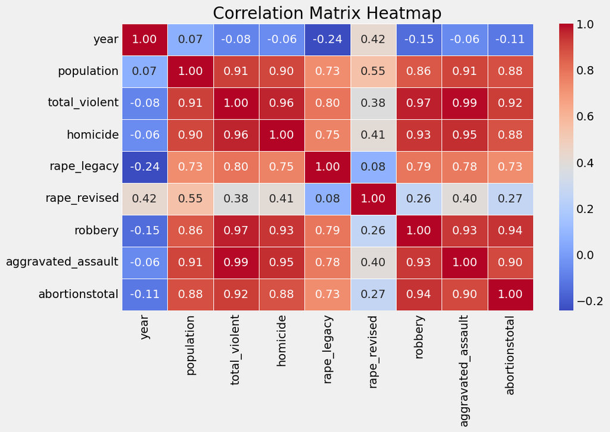

```python
#Correlation heatmap between abortion and the different types of violent crime as well as overall violent crime numbers

chosen_columns = abvi[['year', 'population', 'total_violent', 'homicide',
       'rape_legacy', 'rape_revised', 'robbery', 'aggravated_assault',
       'abortionstotal']]
correlation_matrix = chosen_columns.corr()

plt.figure(figsize=(10, 6))
sns.heatmap(correlation_matrix, annot=True, cmap="coolwarm", fmt=".2f", linewidths=0.5)

plt.title("Correlation Matrix Heatmap")
plt.show()
```

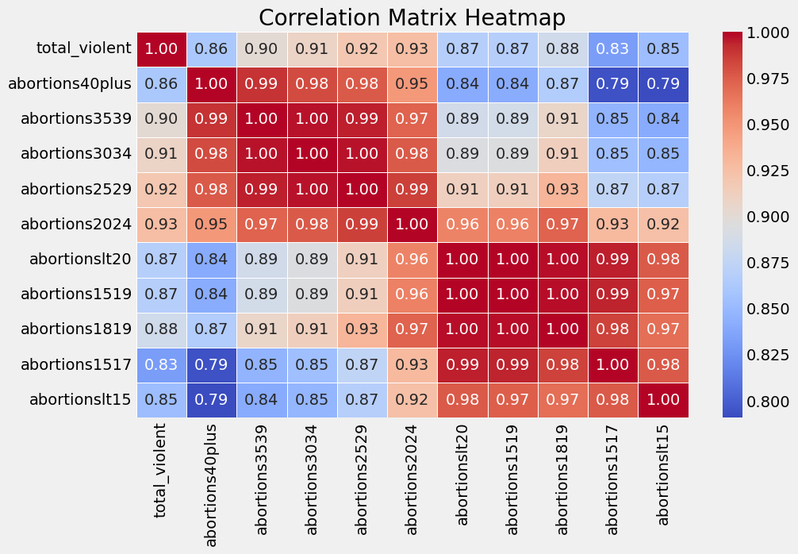

```python
#Correlation heatmap between different types of abortion and overall violent crime numbers
chosen_columns = abvi[['total_violent',
       'abortions40plus', 'abortions3539', 'abortions3034', 'abortions2529',
       'abortions2024', 'abortionslt20', 'abortions1519', 'abortions1819',
       'abortions1517', 'abortionslt15',]]
correlation_matrix = chosen_columns.corr()

plt.figure(figsize=(10, 6))
sns.heatmap(correlation_matrix, annot=True, cmap="coolwarm", fmt=".2f", linewidths=0.5)

plt.title("Correlation Matrix Heatmap")
plt.show()
```

# **Visualizations**

## Time Series Line Graph

```python
# divide by 1e6 to have the values be in millions for easier plotting.
abvi_by_year = abvi[['year', 'total_violent', 'abortionstotal']].groupby('year').agg("sum") / 1e6
#abvi_by_year.head()
```

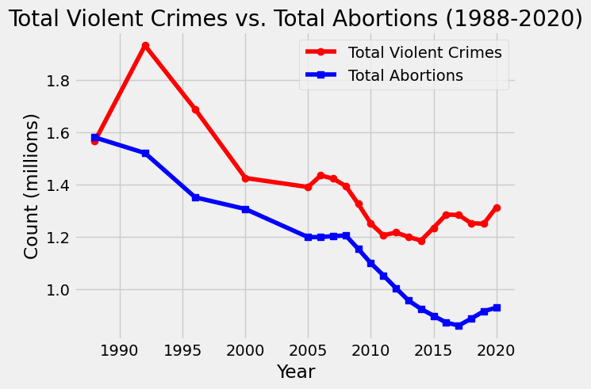

```python
# create time series line plot
plt.plot(abvi_by_year.index, abvi_by_year["total_violent"], marker='o', label="Total Violent Crimes", color='red')
plt.plot(abvi_by_year.index, abvi_by_year["abortionstotal"], marker='s', label="Total Abortions", color='blue')

# Labels and title
plt.xlabel("Year")
plt.ylabel("Count (millions)")
plt.title("Total Violent Crimes vs. Total Abortions (1988-2020)")
plt.legend()
plt.grid(True)

# Show plot
plt.show()
```

## Box Plot

```python
abortion[['year', 'state', 'abortionratetotal']].head()
```

|  | year | state | abortionratetotal |
| --- | --- | --- | --- |
| 0 | 1988 | AL | 21.3 |
| 1 | 1992 | AL | 18.4 |
| 2 | 1996 | AL | 15.3 |
| 3 | 2000 | AL | 13.5 |
| 4 | 2005 | AL | 11.4 |

```python
box_abor = abortion[['year', 'state', 'abortionstotal']]
box_pop = pop[['year', 'state', 'population1544']]
box_vio = violent[['year', "state", "total_violent", 'population']]
box_pav = box_pop.merge(box_abor, on = ['year', 'state']).merge(box_vio, on = ['year', 'state'])

# Abortion rate = (total abortions / population 15-44 female (half total population)) * 1,000
box_pav['abortion_rate'] = (box_pav['abortionstotal'] / round(box_pav['population1544'] / 2)) * 1000
# this is getting a value 2 times larger than that in abortion table for abortion rate

# Crime rates = (total reported crimes / total pop) * 100,000
box_pav['crime_rate'] = (box_pav['total_violent'] / box_pav['population']) * 100000

box_pav = box_pav[['year', 'state', 'abortion_rate', 'crime_rate']]
#box_pav.head()
```

Since we have far too many year and state entries to make a understandable box plot, we will instead focus on a few select years and the top and bottom 5 states in terms of abortion rates for our comparison.

```python
# year 1988

box_pav_1988 = box_pav[box_pav['year'] == 1988].sort_values('abortion_rate', ascending = False)
top5_1988 = box_pav_1988.head(5).assign(group='High Abortion Access')
bot5_1988 = box_pav_1988.tail(5).assign(group='Low Abortion Access')

box_1988 = pd.concat([top5_1988, bot5_1988])
```

```python
list(top5_1988['state'])
```

```
['DC', 'CA', 'HI', 'NY', 'NV']
```

```python
# year 2000

box_pav_2000 = box_pav[box_pav['year'] == 2000].sort_values('abortion_rate', ascending = False)
top5_2000 = box_pav_2000.head(5).assign(group='High Abortion Access')
bot5_2000 = box_pav_2000.tail(5).assign(group='Low Abortion Access')

box_2000 = pd.concat([top5_2000, bot5_2000])
```

```python
# year 2010

box_pav_2010 = box_pav[box_pav['year'] == 2010].sort_values('abortion_rate', ascending = False)
top5_2010 = box_pav_2010.head(5).assign(group='High Abortion Access')
bot5_2010 = box_pav_2010.tail(5).assign(group='Low Abortion Access')

box_2010 = pd.concat([top5_2010, bot5_2010])
```

```python
# year 2020

box_pav_2020 = box_pav[box_pav['year'] == 2020].sort_values('abortion_rate', ascending = False)
top5_2020 = box_pav_2020.head(5).assign(group='High Abortion Access')
bot5_2020 = box_pav_2020.tail(5).assign(group='Low Abortion Access')

box_2020 = pd.concat([top5_2020, bot5_2020])
```

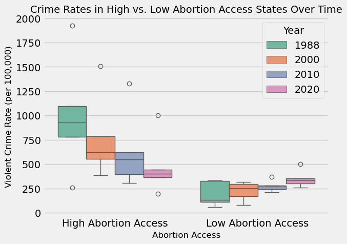

```python
box_df = pd.concat([box_1988, box_2000, box_2010, box_2020])

sns.boxplot(x='group', y='crime_rate', hue='year', data=box_df, palette='Set2')

plt.title("Crime Rates in High vs. Low Abortion Access States Over Time", fontsize=14)
plt.ylabel("Violent Crime Rate (per 100,000)", fontsize=12)
plt.xlabel("Abortion Access", fontsize=12)
plt.legend(title="Year", loc="upper right")

# Show plot
plt.show()
```